# Classification of Point-Like X-ray Sources in the ROSAT 2RXS Survey

Name: Lauren Janicke

Fall 2020

## Introduction

There are many telescopes that have collected data at different wavelengths on the electromagnetic spectrum for distant astronomical bodies. One of these was the *ROSAT* telescope, which observed X-rays emitted by astronomical objects. X-rays are emitted from energetic environments, like the areas around supermassive black holes at the centers of galaxies. Many detected X-ray sources are point-like, and it is difficult to classify them without collecting more data at other wavelengths and visually inspecting them. Here, we will attempt to learn a classifier given ROSAT data and data from three other telescopes: *Gaia*, *Sloan Digital Sky Survey*, and *Wide-field Infrared Survey Explorer*.

**In this project, I will attempt to classify objects observed by ROSAT as either quasars, galaxies whose light is dominated by emission from around supermassive black holes, or normal galaxies**

## Data

The data include 4198 astronomical bodies and 26 predictor variables. These variables are generally brightness measurements made at a number of different wavelengths. The predictor variables are further described in the table.

| Variable | Description |
| --- | --- |
| RXS_ExiML | Detection likelihood |
| RXS_CRate | Source X-ray count rate |
| RXS_Ext | Source extent in pixels |
| RXS_LOGGALNH | Hydrogen column density |
| RXS_SRC_FLUX | Source flux |
| ALLW_(W1, W2, W3, W4, J, H, K)mag | Source magnitudes, in 7 infrared bands |
| SSDS_MODELMAG_(u, g, r, i, z) | Source magnitudes, in 5 optical and near infrared bands |
| SDSS_FIBER2MA_(u, g, r, i, z) | Different source magnitudes, in 5 optical and near infrared bands |
| Z_BEST | Source redshift – a measure of source distance |
| GAIA_DR2_phot_(g, bp, rp)_mean_mag | Source magnitudes, in 3 optical bands |

## EDA

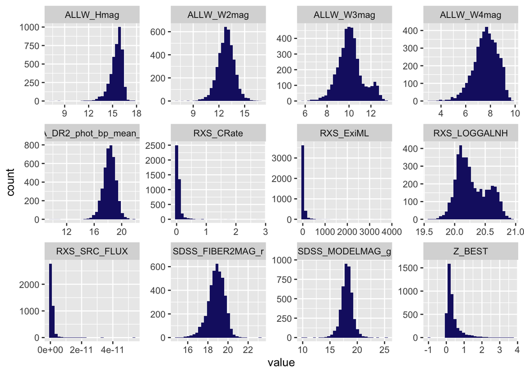

```r
suppressMessages(library(plyr))
suppressMessages(library(tidyverse))
suppressMessages(library(GGally))
suppressMessages(library(purrr))
suppressMessages(library(MASS))
suppressMessages(library(caret))
suppressMessages(library(pROC))
suppressMessages(library(ff))
suppressMessages(library(glmnet))

predictors.plt = dplyr::select(predictors, RXS_ExiML, RXS_SRC_FLUX, RXS_LOGGALNH, RXS_CRate, ALLW_Hmag, ALLW_W2mag, ALLW_W3mag, ALLW_W4mag, SDSS_MODELMAG_g, SDSS_FIBER2MAG_r, GAIA_DR2_phot_bp_mean_mag, Z_BEST)

ggplot(data=gather(predictors.plt), mapping=aes(x=value)) + geom_histogram(fill='midnightblue') + facet_wrap(~key, scales='free')
```

```r
resp.char = trimws(as.character(response))
ind.star=which(resp.char=="STAR")
pred = predictors %>% dplyr::slice(-ind.star)
pred.plot = predictors.plt %>% dplyr::slice(-ind.star)
resp.char = resp.char[-ind.star]
resp = factor(resp.char)
resp = sortLevels(revalue(resp, c("NLAGN"="GALAXY", "BLAGN"="QSO")))
```

Some variables were excluded because they have very similar distributions to the ones plotted. `ALLW_Hmag` is skewed left, unimodal, and contains outliers. `ALLLW_W2mag`, `GAIA_DR2_phot_bp_mean_mag`, `SDSS_FIBER2MAG_r`, and `SDSS_MODELMAG_g` appear symmetrical and unimodal with outliers. `ALLW_W3mag` is not symmetrical, unimodal, and has some outliers. `ALLW_W4mag` is skewed left, unimodal, has outliers at the lower end, and has a wider distribution than other variables. `RXS_LOGGALNH` is not symmetrical, bimodal, and does not appear to have any outliers. It appears that `RXS_CRate`, `RXS_ExiML`, `RXS_SRC_FLUX` and `Z_BEST` are heavily influended by outliers, so these variables will be log-transformed. The following analyses will consider the original and log-transformed data separately.

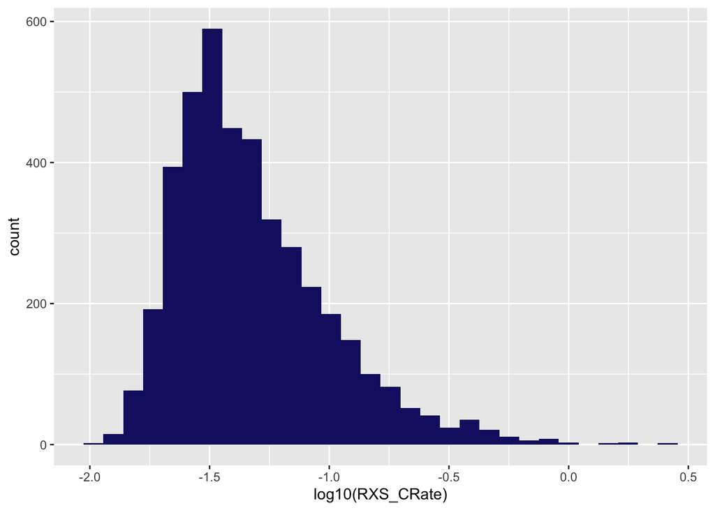

```r
ggplot(predictors.plt, mapping = aes(x=log10(RXS_CRate))) + geom_histogram(fill='midnightblue')
```

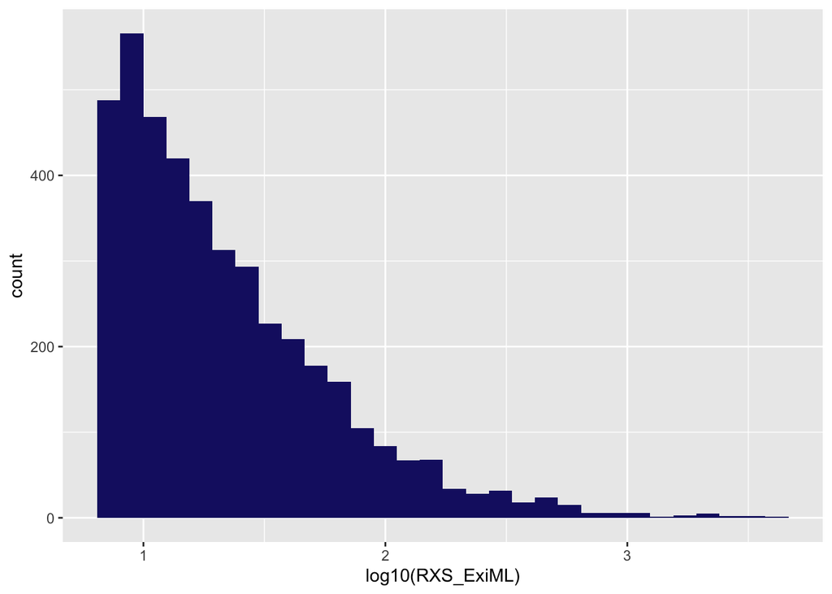

```r
ggplot(predictors.plt, mapping = aes(x=log10(RXS_ExiML))) + geom_histogram(fill='midnightblue')
```

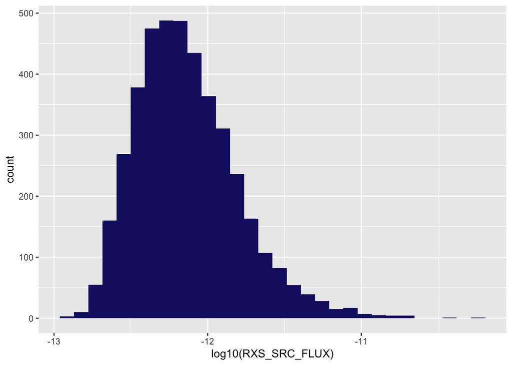

```r
ggplot(predictors.plt, mapping = aes(x=log10(RXS_SRC_FLUX))) + geom_histogram(fill='midnightblue')
```

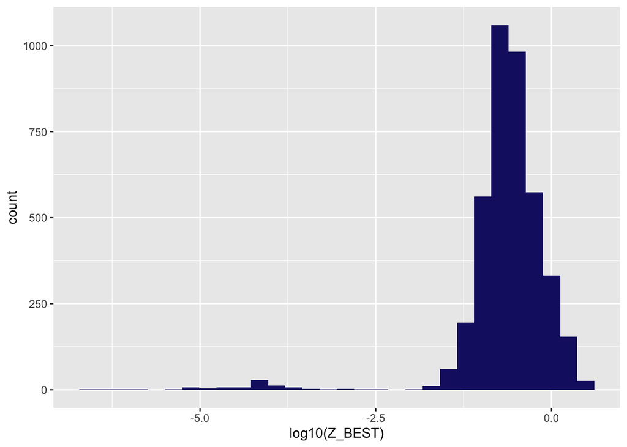

```r
ggplot(predictors.plt, mapping = aes(x=log10(Z_BEST))) + geom_histogram(fill='midnightblue')
```

`RXS_CRate` is unimodal, skewed right, and contains outliers. `RXS_ExiML` is unimodal and skewed right. `RXS_SRC_FLUX` is unimodal and fairly symmetric with outliers to the right. `Z_BEST` is unimodal, skewed left, and also contains outliers. A smaller selection of these variables will be taken to be plotted against each other with the response variable. The previously log-transformed variables will remained log-transformed for better visualization. In order to show only the quasars and galaxies as the response variables, the star class is removed from both the response and predictor variables.

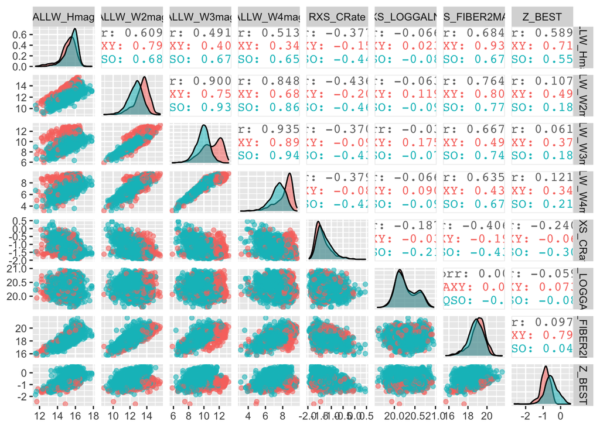

```r
predictors.plt2 = dplyr::select(pred, ALLW_Hmag, ALLW_W2mag, ALLW_W3mag, ALLW_W4mag, RXS_CRate, RXS_LOGGALNH, SDSS_FIBER2MAG_r, Z_BEST)
predictors.plt2 = predictors.plt2 %>% mutate(RXS_CRate=log10(RXS_CRate), Z_BEST=log10(Z_BEST))
ggpairs(predictors.plt2, mapping=aes(color=resp, alpha=0.3), progress = FALSE)
```

Principal component analysis will be used to see if a subset of the original predictors are the main conrtibutors to the important principal components.

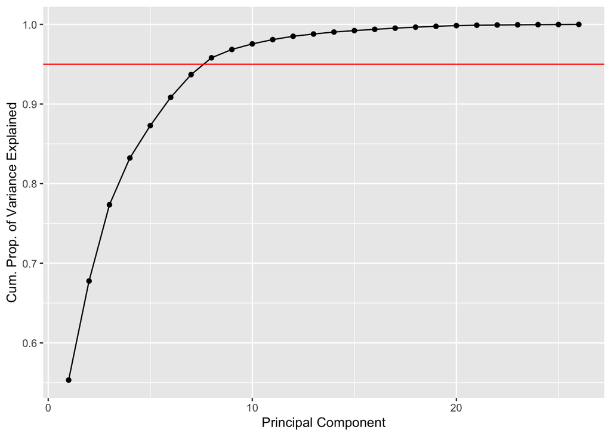

```r
pr.out = prcomp(predictors, scale=TRUE)
pr.var = pr.out$sdev ^2
pve = pr.var/sum(pr.var)
ggplot(data.frame(pve=pve, num=1:26), mapping = aes(x=num, y=cumsum(pve))) + geom_line() + geom_point() + labs(x='Principal Component', y='Cum. Prop. of Variance Explained') + geom_hline(yintercept=0.95, color='red')
```

```r
round(pr.out$rotation[,1:8],3)
```

```
##                              PC1    PC2    PC3    PC4    PC5    PC6    PC7
## RXS_ExiML                  0.099  0.001 -0.546  0.145 -0.076  0.127 -0.046
## RXS_CRate                  0.113  0.006 -0.553  0.140 -0.015  0.061 -0.019
## RXS_Ext                    0.032  0.000 -0.130  0.066  0.548 -0.818 -0.006
## RXS_LOGGALNH               0.001 -0.078  0.034 -0.236 -0.746 -0.518  0.245
## RXS_SRC_FLUX               0.115 -0.013 -0.531  0.082 -0.181 -0.071  0.034
## ALLW_W1mag                -0.230 -0.008  0.028  0.327 -0.055 -0.007  0.111
## ALLW_W2mag                -0.209 -0.179  0.031  0.351 -0.040 -0.001  0.161
## ALLW_W3mag                -0.172 -0.282  0.052  0.406 -0.071 -0.047  0.088
## ALLW_W4mag                -0.171 -0.224  0.077  0.415 -0.025 -0.024  0.133
## ALLW_Jmag                 -0.216  0.283 -0.048  0.001  0.006 -0.002  0.148
## ALLW_Hmag                 -0.211  0.291 -0.021  0.084 -0.022 -0.005  0.131
## ALLW_Kmag                 -0.219  0.220  0.018  0.212 -0.042 -0.008  0.116
## SDSS_MODELMAG_u           -0.194 -0.302 -0.037 -0.041 -0.073 -0.041 -0.385
## SDSS_MODELMAG_g           -0.241 -0.096 -0.076 -0.104 -0.062 -0.042 -0.272
## SDSS_MODELMAG_r           -0.240  0.097 -0.074 -0.079 -0.075 -0.055 -0.214
## SDSS_MODELMAG_i           -0.224  0.208 -0.052 -0.027 -0.082 -0.057 -0.158
## SDSS_MODELMAG_z           -0.216  0.272 -0.052 -0.003 -0.069 -0.048 -0.100
## SDSS_FIBER2MAG_u          -0.176 -0.375 -0.031 -0.077  0.010  0.002 -0.224
## SDSS_FIBER2MAG_g          -0.222 -0.239 -0.078 -0.173  0.054  0.022 -0.100
## SDSS_FIBER2MAG_r          -0.246 -0.060 -0.093 -0.188  0.066  0.020 -0.014
## SDSS_FIBER2MAG_i          -0.245  0.087 -0.073 -0.130  0.063  0.022  0.071
## SDSS_FIBER2MAG_z          -0.237  0.164 -0.078 -0.106  0.077  0.032  0.143
## Z_BEST                    -0.025  0.322  0.116  0.283 -0.137 -0.097 -0.583
## GAIA_DR2_phot_g_mean_mag  -0.215 -0.125 -0.094 -0.195  0.156  0.092  0.264
## GAIA_DR2_phot_bp_mean_mag -0.238 -0.134 -0.088 -0.157  0.040  0.033  0.001
## GAIA_DR2_phot_rp_mean_mag -0.242  0.133 -0.084 -0.109  0.056  0.030  0.146
##                              PC8
## RXS_ExiML                  0.030
## RXS_CRate                  0.006
## RXS_Ext                   -0.002
## RXS_LOGGALNH               0.124
## RXS_SRC_FLUX               0.047
## ALLW_W1mag                 0.075
## ALLW_W2mag                 0.057
## ALLW_W3mag                -0.136
## ALLW_W4mag                -0.078
## ALLW_Jmag                 -0.024
## ALLW_Hmag                 -0.002
## ALLW_Kmag                  0.054
## SDSS_MODELMAG_u           -0.093
## SDSS_MODELMAG_g           -0.197
## SDSS_MODELMAG_r           -0.307
## SDSS_MODELMAG_i           -0.331
## SDSS_MODELMAG_z           -0.260
## SDSS_FIBER2MAG_u           0.148
## SDSS_FIBER2MAG_g           0.125
## SDSS_FIBER2MAG_r           0.057
## SDSS_FIBER2MAG_i           0.054
## SDSS_FIBER2MAG_z           0.122
## Z_BEST                     0.613
## GAIA_DR2_phot_g_mean_mag   0.379
## GAIA_DR2_phot_bp_mean_mag  0.165
## GAIA_DR2_phot_rp_mean_mag  0.144
```

In order to retain 95% of the data varability, 8 principal components were retained. PC1 and PC2 are not very strongly correlated to any variable. PC3 is strongly tied to `RXS_ExiML`, `RXS_CRate`, and `RXS_SRC_FLUX`. PC4 is tied to `ALLW_W3mag` and `ALLW_W4mag`. PC5 and PC6 is strongly tied to `RXS_Ext` and `RXS_LOGGALNH`. PC7 is tied to `SDSS_MODELMAG_u` and `Z_BEST`. PC8 is strongly tied to `Z_BEST`.

## Analyses

### Splitting Data

This data will be split into training and testing data. The training data will contain 70% of the data (2768 bodies), and the testing data will contain the remaining 30% of the data (1187 bodies).

```r
set.seed(101)

indices = sample(length(resp), floor(0.7*length(resp)))
predlog = pred %>% mutate(RXS_CRate = log10(RXS_CRate), Z_BEST = log10(Z_BEST), RXS_ExiML = log10(RXS_ExiML), RXS_SRC_FLUX=log10(RXS_SRC_FLUX))
pred.train = pred %>% dplyr::slice(indices)
pred.test = pred %>% dplyr::slice(-indices)
predlog.train = predlog %>% dplyr::slice(indices)
predlog.test = predlog %>% dplyr::slice(-indices)
resp.train = resp[indices]
resp.test = resp[-indices]
```

### Logistic Regression with Full Dataset

Forward and backward stepwise selection is used as way to address multicollinearity in the data. Lasso and ridge regression, two types of penalized regression, may also address multicollinearity.

```r
#Logistic Regression
log.out = glm(resp.train~., pred.train, family=binomial)
log.prob = predict(log.out, pred.test, type='response')
roc.log = roc(resp.test, log.prob)
auc.log = round(roc.log$auc,4)
auc.log
```

```
## [1] 0.9467
```

```r
#Forward/Backward Stepwise Selection
forward.out = log_forward(pred.train=pred.train)
backward.out = log_backward(pred.train = pred.train)

df.fss = pred.train %>% dplyr::select(forward.out)
```

```
## Note: Using an external vector in selections is ambiguous.
## ℹ Use `all_of(forward.out)` instead of `forward.out` to silence this message.
## ℹ See <https://tidyselect.r-lib.org/reference/faq-external-vector.html>.
```

```r
df.bss = pred.train %>% dplyr::select(backward.out)
```

```
## Note: Using an external vector in selections is ambiguous.
## ℹ Use `all_of(backward.out)` instead of `backward.out` to silence this message.
## ℹ See <https://tidyselect.r-lib.org/reference/faq-external-vector.html>.
```

```r
log.fss.out = glm(resp.train~., df.fss, family=binomial)
log.fss.prob = predict(log.fss.out, newdata=pred.test, type="response")
roc.log.fss = roc(resp.test, log.fss.prob)
auc.log.fss = round(roc.log.fss$auc,4)
J.logfss=max(roc.log.fss$sensitivities + roc.log.fss$specificities -1)
logfss.pred = factor(ifelse(log.fss.prob>J.logfss, "QSO", "GALAXY"))
tab.logfss = table(logfss.pred, resp.test)
MCR.logfss = sum(ifelse(logfss.pred!=resp.test, 1, 0)) / length(resp.test)
auc.log.fss
```

```
## [1] 0.9479
```

```r
log.bss.out = glm(resp.train~., df.bss, family=binomial)
log.bss.prob = predict(log.bss.out, newdata=pred.test, type="response")
roc.log.bss = roc(resp.test, log.bss.prob)
auc.log.bss = round(roc.log.bss$auc,4)
auc.log.bss
```

```
## [1] 0.9478
```

```r
#Ridge regression
x = model.matrix(resp.train~., pred.train)
ridge.out = glmnet(x, resp.train, alpha=0, family='binomial')

set.seed(101)
cv.ridge.out = cv.glmnet(x, resp.train, alpha=0, family='binomial')
ridge.bestlam=cv.ridge.out$lambda.min

x.test = model.matrix(resp.test~., pred.test)
ridge.prob = predict(ridge.out, s=ridge.bestlam, newx=x.test)
roc.ridge = roc(resp.test, ridge.prob)
auc.ridge = round(roc.ridge$auc,4)
auc.ridge
```

```
## [1] 0.9321
```

```r
#Lasso Regression
y = model.matrix(resp.train~., pred.train)
lasso.out = glmnet(y, resp.train, alpha=1, family='binomial')

set.seed(101)
cv.lasso.out = cv.glmnet(y, resp.train, alpha=1, family='binomial')
lasso.bestlam=cv.lasso.out$lambda.min

y.test = model.matrix(resp.test~., pred.test)
lasso.prob = predict(lasso.out, s=lasso.bestlam, newx=y.test)
roc.lasso = roc(resp.test, lasso.prob)
auc.lasso = round(roc.lasso$auc,4)
auc.lasso
```

```
## [1] 0.9447
```

### Logistic Regression with Reduced Dataset

The variance inflation factor (VIF) is also used to address the multicollinearity of the data.

```r
library(car)
THRESHOLD = 10
pred.vif = pred.train
istop = 0
while ( istop == 0 ) {
  log.out = glm(resp.train~.,data=pred.vif,family=binomial)
  v = vif(log.out)
  if ( max(v) > THRESHOLD ) {
    pred.vif = pred.vif[,-which.max(v)]
  } else {
    istop = 1
  }
}
print(v)
```

```
##                RXS_ExiML                  RXS_Ext             RXS_LOGGALNH
##                 1.105268                 1.028357                 1.051325
##               ALLW_W2mag               ALLW_W4mag                ALLW_Hmag
##                 6.507736                 2.963580                 7.830013
##          SDSS_MODELMAG_i         SDSS_FIBER2MAG_u                   Z_BEST
##                 5.706412                 2.959110                 1.529988
## GAIA_DR2_phot_g_mean_mag
##                 5.513706
```

```r
log.vif.out = glm(resp.train~., pred.vif, family=binomial) ##DF1 IS WHAT WOULD CHANGE
log.vif.prob = predict(log.vif.out, newdata=pred.test, type="response")
roc.log.vif = roc(resp.test, log.vif.prob)
auc.log.vif = round(roc.log.vif$auc,4)
auc.log.vif
```

```
## [1] 0.9329
```

```r
#Forward/Backward Stepwise Selection
pred.fssvif = df.fss
istop = 0
while ( istop == 0 ) {
  log.out = glm(resp.train~.,data=pred.fssvif,family=binomial)
  v = vif(log.out)
  if ( max(v) > THRESHOLD ) {
    pred.fssvif = pred.fssvif[,-which.max(v)]
  } else {
    istop = 1
  }
}
print(v)
```

```
##               ALLW_W2mag               ALLW_W3mag               ALLW_W4mag
##                 7.790679                 9.760884                 6.808002
## GAIA_DR2_phot_g_mean_mag             RXS_LOGGALNH         SDSS_FIBER2MAG_u
##                 5.514786                 1.054935                 3.208311
##          SDSS_MODELMAG_z                   Z_BEST
##                 3.907186                 2.007695
```

```r
log.viffss.out = glm(resp.train~., pred.fssvif, family=binomial)
log.viffss.prob = predict(log.viffss.out, newdata=pred.test, type="response")
roc.log.viffss = roc(resp.test, log.viffss.prob)
auc.log.viffss = round(roc.log.viffss$auc,4)
auc.log.viffss
```

```
## [1] 0.9249
```

```r
pred.bssvif = df.bss
istop = 0
while ( istop == 0 ) {
  log.out = glm(resp.train~.,data=pred.bssvif,family=binomial)
  v = vif(log.out)
  if ( max(v) > THRESHOLD ) {
    pred.bssvif = pred.bssvif[,-which.max(v)]
  } else {
    istop = 1
  }
}
print(v)
```

```
##                ALLW_Kmag               ALLW_W2mag               ALLW_W4mag
##                 9.719575                 7.612721                 2.901759
## GAIA_DR2_phot_g_mean_mag             RXS_LOGGALNH         SDSS_FIBER2MAG_u
##                 5.548591                 1.053749                 2.981922
##          SDSS_MODELMAG_z                   Z_BEST
##                 6.399643                 1.777722
```

```r
log.vifbss.out = glm(resp.train~., pred.bssvif, family=binomial)
log.vifbss.prob = predict(log.vifbss.out, newdata=pred.test, type="response")
roc.log.vifbss = roc(resp.test, log.vifbss.prob)
auc.log.vifbss = round(roc.log.vifbss$auc,4)
auc.log.vifbss
```

```
## [1] 0.931
```

```r
#Ridge regression
xvif = model.matrix(resp.train~., pred.vif)
ridgevif.out = glmnet(xvif, resp.train, alpha=0, family='binomial')

cv.ridgevif.out = cv.glmnet(xvif, resp.train, alpha=0, family='binomial')
ridgevif.bestlam=cv.ridgevif.out$lambda.min

pred.test.vif = pred.test %>% dplyr::select(RXS_ExiML, RXS_Ext, RXS_LOGGALNH, ALLW_W2mag, ALLW_W4mag, ALLW_Hmag, SDSS_MODELMAG_i, SDSS_FIBER2MAG_u, Z_BEST, GAIA_DR2_phot_g_mean_mag)
x.test.vif = model.matrix(resp.test~., pred.test.vif)
ridgevif.prob = predict(ridgevif.out, s=ridgevif.bestlam, newx=x.test.vif)
roc.ridgevif = roc(resp.test, ridgevif.prob)
auc.ridgevif = round(roc.ridgevif$auc,4)
auc.ridgevif
```

```
## [1] 0.9302
```

```r
#Lasso regression
lassovif.out = glmnet(xvif, resp.train, alpha=1, family='binomial')

cv.lassovif.out = cv.glmnet(xvif, resp.train, alpha=1, family='binomial')
lassovif.bestlam=cv.lassovif.out$lambda.min
lassovif.prob = predict(lassovif.out, s=lassovif.bestlam, newx=x.test.vif)
roc.lassovif = roc(resp.test, lassovif.prob)
auc.lassovif = round(roc.lassovif$auc,4)
auc.lassovif
```

```
## [1] 0.9334
```

### Linear Discriminant Analysis

For linear discriminant analysis, `RXS_SRC_FLUX` was logged-transformed in order to differentiate the values more and complete the analysis.

```r
lda.pred.train = pred.train %>% mutate(RXS_SRC_FLUX=log(RXS_SRC_FLUX, 10))
lda.out = lda(resp.train~., data=lda.pred.train)
lda.predict= predict(lda.out, pred.test, type='prob')
lda.prob = lda.predict$posterior[,2]
roc.lda = roc(resp.test, lda.prob)
auc.lda = round(roc.lda$auc,4)
auc.lda
```

```
## [1] 0.9356
```

```r
#tab.lda = table(lda.predict$class, resp.test)
#MCR.lda = sum(ifelse(lda.predict$class!=resp.test, 1, 0)) / length(resp.test)
```

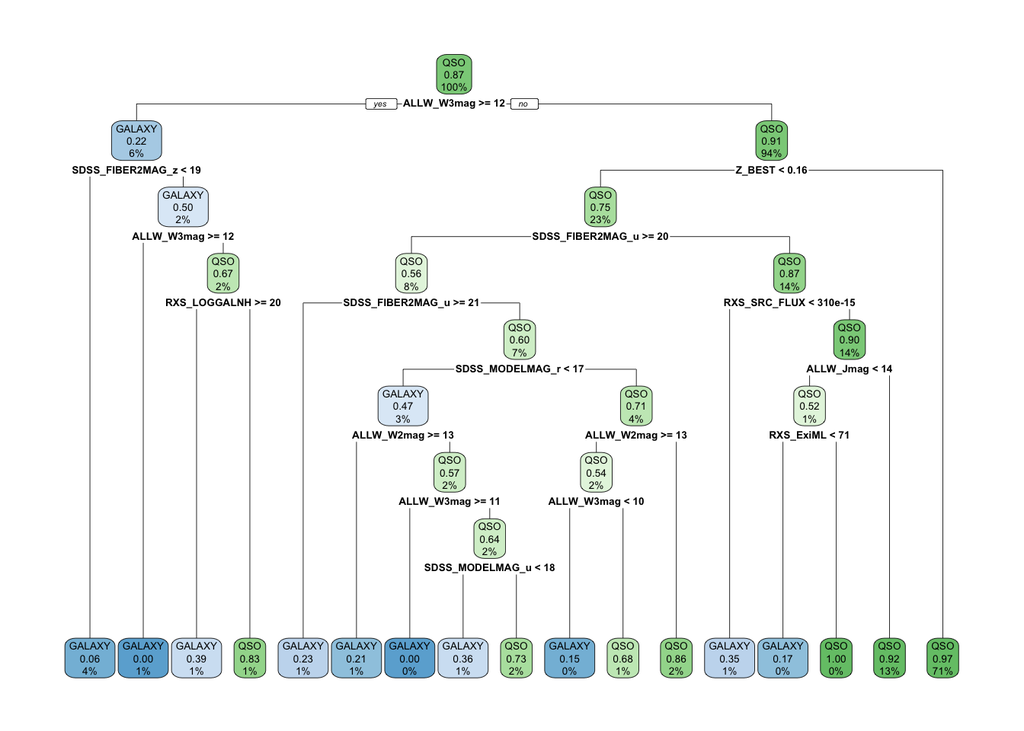

```r
library(rpart)
library(rpart.plot)
tree.out = rpart(resp.train~., pred.train)
rpart.plot(tree.out)
```

```r
printcp(tree.out)
```

```
##
## Classification tree:
## rpart(formula = resp.train ~ ., data = pred.train)
##
## Variables actually used in tree construction:
##  [1] ALLW_Jmag        ALLW_W2mag       ALLW_W3mag       RXS_ExiML
##  [5] RXS_LOGGALNH     RXS_SRC_FLUX     SDSS_FIBER2MAG_u SDSS_FIBER2MAG_z
##  [9] SDSS_MODELMAG_r  SDSS_MODELMAG_u  Z_BEST
##
## Root node error: 363/2768 = 0.13114
##
## n= 2768
##
##         CP nsplit rel error  xerror     xstd
## 1 0.278237      0   1.00000 1.00000 0.048924
## 2 0.022039      1   0.72176 0.76309 0.043495
## 3 0.014692      3   0.67769 0.76309 0.043495
## 4 0.012397     10   0.55647 0.74931 0.043144
## 5 0.011019     12   0.53168 0.74931 0.043144
## 6 0.010000     16   0.48760 0.73829 0.042860
```

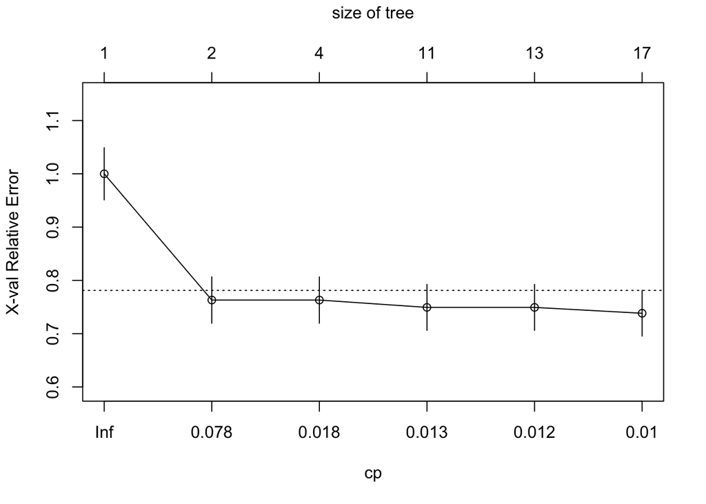

```r
plotcp(tree.out)
```

```r
tree.out = prune.rpart(tree.out, cp=0.022039)
printcp(tree.out)
```

```
##
## Classification tree:
## rpart(formula = resp.train ~ ., data = pred.train)
##
## Variables actually used in tree construction:
## [1] ALLW_W3mag
##
## Root node error: 363/2768 = 0.13114
##
## n= 2768
##
##         CP nsplit rel error  xerror     xstd
## 1 0.278237      0   1.00000 1.00000 0.048924
## 2 0.022039      1   0.72176 0.76309 0.043495
```

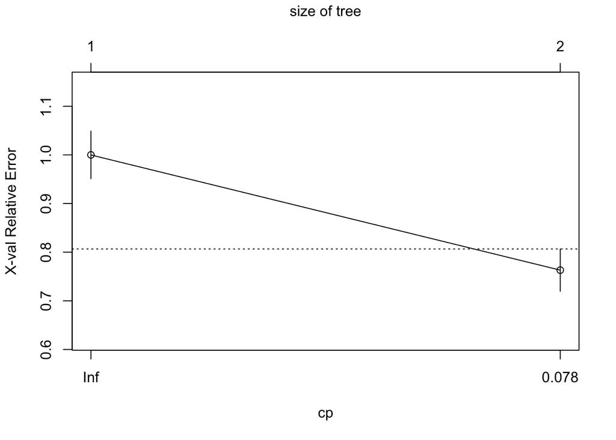

```r
plotcp(tree.out)
```

```r
tree.prob = predict(tree.out, newdata=pred.test, type='prob')
roc.tree = roc(resp.test, tree.prob[,2])
auc.tree = round(roc.tree$auc,4)
auc.tree
```

```
## [1] 0.7073
```

```r
# tree.pred = factor(ifelse(tree.prob[,2]>0.5, "QSO", "GALAXY"))
# tab.tree = table(tree.pred, resp.test)
# MCR.tree = sum(ifelse(tree.pred!=resp.test, 1, 0)) / length(resp.test)
```

### Random Forest

```r
library(randomForest)
set.seed(101)
rf.out = randomForest(factor(resp.train)~., pred.train, importance=TRUE)
rf.prob = predict(rf.out, pred.test, type='prob')
roc.rf = roc(resp.test, rf.prob[,2])
auc.rf = round(roc.rf$auc,4)
auc.rf
```

```
## [1] 0.9325
```

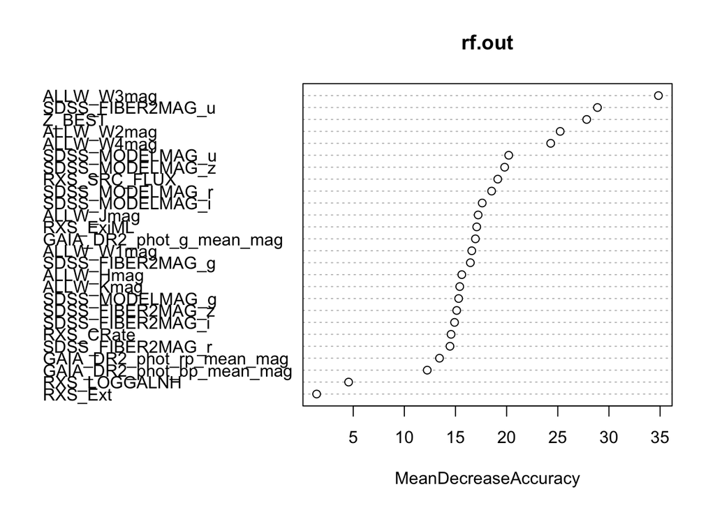

```r
varImpPlot(rf.out, type=1)
```

```r
# rf.pred = factor(ifelse(rf.prob[,2]>0.5, "QSO", "GALAXY"))
# tab.rf = table(rf.pred, resp.test)
# MCR.rf = sum(ifelse(rf.pred!=resp.test, 1, 0)) / length(resp.test)
```

### Boosting

```r
library(xgboost)
resp.train.b = ifelse(resp.train=='GALAXY', 0, 1)
resp.test.b = ifelse(resp.test=='GALAXY', 0, 1)
train = xgb.DMatrix(data=as.matrix(pred.train), label=resp.train.b)
test = xgb.DMatrix(data=as.matrix(pred.test), label=resp.test.b)
xgb.out = xgb.cv(train, nfold=20, nrounds=20, params=list(objective="binary:logistic"), verbose=0)
opt = which.min(xgb.out$evaluation_log$test_error_mean)
boost.out = xgboost(train, nrounds = opt, params=list(objective="binary:logistic"), verbose=0)
boost.prob = predict(boost.out, test)
roc.boost = roc(resp.test, boost.prob)
auc.boost = round(roc.boost$auc,4)
auc.boost
```

```
## [1] 0.9327
```

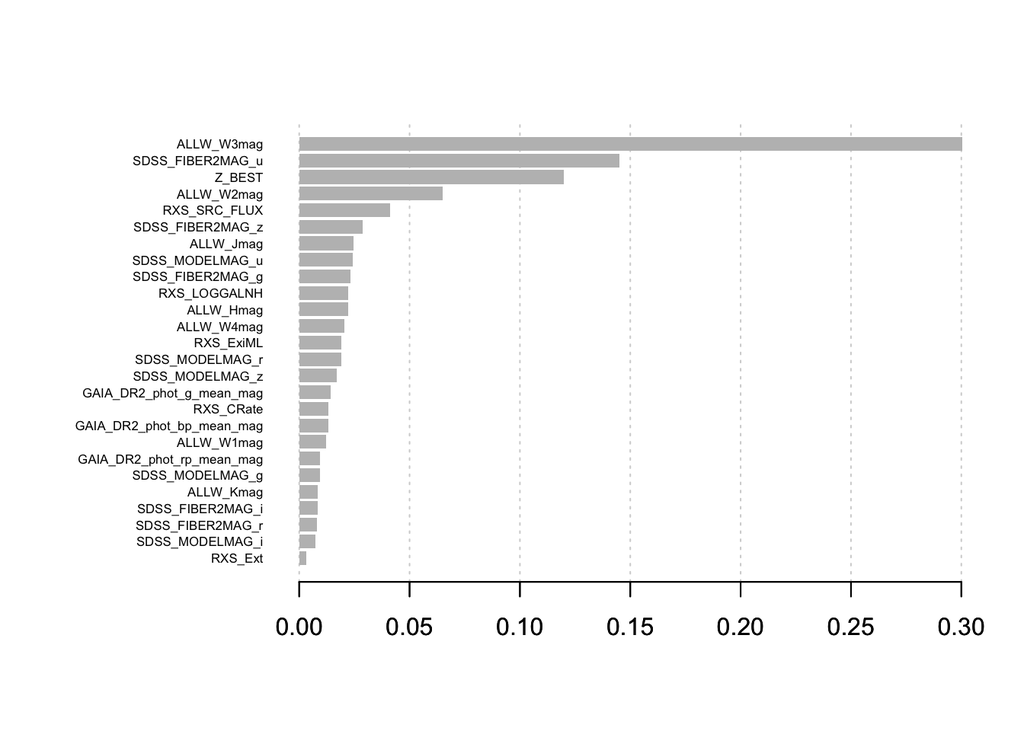

```r
importance.class = xgb.importance(model=boost.out)
xgb.plot.importance(importance.class)
```

```r
# boost.pred = factor(ifelse(boost.prob>0.5, "QSO", "GALAXY"))
# tab.boost = table(boost.pred, resp.test)
# MCR.boost = sum(ifelse(boost.pred!=resp.test, 1, 0)) / length(resp.test)
```

### kNN

```r
library(FNN)
k.max = 15
mcr.k = rep(NA, k.max)
for (ii in 1:k.max) {
  knn.out.temp = knn.cv(pred.train, cl=resp.train, k=ii, algorithm="kd_tree")
  mcr.k[ii] = sum(ifelse(knn.out.temp!=resp.train, 1, 0)) / length(resp.train)
}
k.min = which.min(mcr.k)
k.min
```

```
## [1] 8
```

```r
knn.out = knn(pred.train, pred.test, cl=resp.train, k=k.min, algorithm = 'kd_tree', prob=TRUE)
knn.prob = attr(knn.out, 'prob')
roc.knn = roc(resp.test, knn.prob)
auc.knn = round(roc.knn$auc,4)
auc.knn
```

```
## [1] 0.7013
```

### Naive Bayes

```r
library(naivebayes)
nb.out = naive_bayes(pred.train, resp.train)
nb.prob = predict(nb.out, pred.test, type='prob')[,2]
roc.nb = roc(resp.test, nb.prob)
auc.nb = round(roc.nb$auc,4)
auc.nb
```

```
## [1] 0.8974
```

```r
# nb.pred = factor(ifelse(nb.prob>0.5, "QSO", "GALAXY"))
# tab.nb = table(nb.pred, resp.test)
# MCR.nb = sum(ifelse(nb.pred!=resp.test, 1, 0)) / length(resp.test)
```

### SVM

```r
library(e1071)
set.seed(101)

predicto = rbind(pred.train, pred.test)
predicto = scale(predicto)
len = nrow(pred.train)
pred.train.s = predicto[1:len,]
pred.test.s = predicto[-(1:len),]

#linear
tune.out.lin = tune(svm, train.x = pred.train.s, train.y = resp.train, kernel='linear', ranges=list(cost=c(0.1, 1, 10, 100, 0.01)), probability = TRUE)
svm.pred.lin = predict(tune.out.lin$best.model, newdata = pred.test.s, probability = TRUE)
svm.prob.lin = attr(svm.pred.lin, 'probabilities')
roc.svmlin = roc(resp.test, svm.prob.lin[,2])
auc.svmlin = round(roc.svmlin$auc,4)
auc.svmlin
```

```
## [1] 0.9413
```

```r
# MCR.svm.lin = (sum(ifelse(resp.test != svm.pred.lin, 1, 0))/length(resp.test))
# tab.svm.lin = table(svm.pred.lin, resp.test)

#polynomial
tune.out.poly = tune(svm, train.x = pred.train.s, train.y = resp.train, kernel='polynomial', ranges=list(degree=2:10, cost=c(0.1, 1, 10, 100, 0.01)), probability = TRUE)
svm.pred.poly = predict(tune.out.poly$best.model, newdata = pred.test.s, probability = TRUE)
svm.prob.poly = attr(svm.pred.poly, 'probabilities')
roc.svmpoly = roc(resp.test, svm.prob.poly[,2])
auc.svmpoly = round(roc.svmpoly$auc,4)
auc.svmpoly
```

```
## [1] 0.9208
```

```r
# MCR.svm.poly = (sum(ifelse(resp.test != svm.pred.poly, 1, 0))/length(resp.test))
# tab.svm.poly = table(svm.pred.poly, resp.test)

#radial
tune.out.rad = tune(svm, train.x = pred.train.s, train.y = resp.train, kernel='radial', ranges=list(gamma=1:10, cost=c(0.1, 1, 10, 100, 0.01)), probability = TRUE)
svm.pred.rad = predict(tune.out.rad$best.model, newdata = pred.test.s, probability = TRUE)
svm.prob.rad = attr(svm.pred.rad, 'probabilities')
roc.svmrad = roc(resp.test, svm.prob.rad[,2])
auc.svmrad = round(roc.svmrad$auc,4)
auc.svmrad
```

```
## [1] 0.867
```

```r
# MCR.svm.rad = (sum(ifelse(resp.test != svm.pred.rad, 1, 0))/length(resp.test))
# tab.svm.rad = table(svm.pred.rad, resp.test)
```

### Log-Transformed Data

The previous models will be fitted with the log-transformed data. Their AUCs will be reported below.

### Results

For the regression models, variance inflation factor (VIF) and forward/backward stepwise selection were used to address multicollinearity in the data. For the other models, multicollinearity does not matter as much; however, some models do have some form of variable selection or reveal some variables to be more important than others. For the models that give the importance of variables, the top five most important are listed. A comparison of the selected variables is presented below. We see that `ALLW_W2mag`, `ALLW_W4mag`, `SDSS_FIBER2AMG_u`, and `Z_BEST` appear in at least six of the eight models examined for both datasets. `ALLW_W3mag` is the sole vairable used in the tree model for both datasets.

[output not shown]

The area under the curve (AUC) indicates the prediction power of a model without having the class imbalance affect the metric. Because these data are not balanced, we use the area under the curve to determine the best model. We see that *logisitic regression with forward stepwise selection from the original dataset* has the greatest area under the curve. Additionally, regression models and models created from the original dataset tend to do better than others. Using a VIF-reduced model does not improve the area under the curve, but does improve the inference one has when using that model. If one only cares about prediction rather than multicollinearity, using VIF, forward/backward selection, or penalized regression is not important.

| Test | AUC from Original Dataset | AUC from Log-Transformed Dataset |
| --- | --- | --- |
| Logistic Regression with Forward Stepwise Selection | 0.9479 | 0.9417 |
| Logistic Regression with Backward Stepwise Selection | 0.9478 | 0.9431 |
| Logistic Regression | 0.9467 | 0.9440 |
| Lasso Regression | 0.9447 | 0.9426 |
| Linear SVM | 0.9413 | 0.4976 |
| Linear Discriminant Analysis | 0.9356 | 0.9362 |
| Lasso Regression with VIF | 0.9334 | 0.9291 |
| Logistic Regression with VIF | 0.9329 | 0.9287 |
| Boosting | 0.9327 | 0.9327 |
| Random Forest | 0.9325 | 0.9287 |
| Ridge Regression | 0.9321 | 0.9306 |
| Logistic Regression with VIF and Backward Stepwise Selection | 0.9310 | 0.9306 |
| Ridge Regression with VIF | 0.9302 | 0.9252 |
| Logistic Regression with VIF and Forward Stepwise Selection | 0.9249 | 0.9287 |
| Polynomial SVM | 0.9208 | 0.5819 |
| Naive Bayes | 0.8974 | 0.9131 |
| Radial SVM | 0.8670 | 0.5000 |
| Tree | 0.7073 | 0.7073 |
| kNN | 0.7013 | 0.7040 |

To supplement the discussion, here is more information regarding the best performing model: logistic regression with forward stepwise selection from the original dataset. Note that Youden’s J statistic was used to determine where to classify the data, and it assumes that identifying each class is equally important.

```
## Confusion Matrix for Logistic Regression with forward stepwise selection:
```

```
##            resp.test
## logfss.pred GALAXY QSO
##      GALAXY    125  79
##      QSO        34 949
```

```
## Misclassification Rate for Logistic Regression with forward stepwise selection:
```

```
## [1] 0.0952
```

```
## Specificity for Logistic Regression with forward stepwise selection:
```

```
## [1] 0.8931
```

```
## Sensitivity for Logistic Regression with forward stepwise selection:
```

```
## [1] 0.8609
```

## Conclusions

We were able to successfully classify astonomical objects as quasars or galaxies from brightness data using logistic regression with forward stepwise selection from the original dataset. The area under the curve is 0.9479, and the misclassification rate is 9.52%.